# cohort_p1_data_c659_noedema

Autogenerated data summary from dataReporter

2026-07-12 15:20:43.686698

# Data report overview

The dataset examined has the following dimensions:

| Feature | Result |
| --- | --- |
| Number of observations | 1342 |
| Number of variables | 37 |

### Checks performed

The following variable checks were performed, depending on the data type of each variable:

|  | character | factor | labelled | haven labelled | numeric | integer | logical | Date |
| --- | --- | --- | --- | --- | --- | --- | --- | --- |
| Identify miscoded missing values | × | × | × | × | × | × |  | × |
| Identify prefixed and suffixed whitespace | × | × | × | × |  |  |  |  |
| Identify levels with < 6 obs. | × | × | × | × |  |  |  |  |
| Identify case issues | × | × | × | × |  |  |  |  |
| Identify misclassified numeric or integer variables | × | × | × | × |  |  |  |  |
| Identify outliers |  |  |  |  | × | × |  | × |

Please note that all numerical values in the following have been rounded to 2 decimals.

# Summary table

|  | Variable class | # unique values | Missing observations | Any problems? |
| --- | --- | --- | --- | --- |
| nonresponse_p1 | logical | 2 | 0.00 % |  |
| age_month | numeric | 49 | 0.00 % |  |
| age_group | character | 2 | 0.00 % |  |
| gender | factor | 2 | 0.00 % |  |
| locality | factor | 3 | 0.89 % |  |
| vaccination_status | factor | 3 | 57.38 % |  |
| is_breastfed | factor | 3 | 69.52 % |  |
| admission_type | factor | 3 | 3.28 % |  |
| edema_incident | logical | 2 | 0.00 % |  |
| prop_whz_error_p1 | numeric | 4 | 2.31 % | × |
| length_tubefeeding | numeric | 17 | 0.00 % | × |
| phase_length | integer | 24 | 0.00 % | × |
| is_death_in_phase | logical | 3 | 61.48 % |  |
| death_day1_in_phase | logical | 3 | 0.89 % |  |
| nutri_treat_p1 | factor | 5 | 0.07 % |  |
| f75_to_f75f | logical | 2 | 0.00 % |  |
| prop_familymeals_p1 | numeric | 18 | 0.00 % | × |
| prop_food_intolerance_p1 | numeric | 3 | 65.35 % |  |
| prop_f75x_freq_less_p1 | numeric | 8 | 41.36 % | × |
| prop_f75x_freq_more_p1 | numeric | 6 | 41.36 % | × |
| prop_f75x_qty_less_p1 | numeric | 29 | 1.12 % | × |
| prop_f75x_qty_more_p1 | numeric | 46 | 1.12 % |  |
| prop_f75x_adh_less_p1 | numeric | 52 | 1.12 % |  |
| prop_f75x_adh_more_p1 | numeric | 33 | 1.12 % | × |
| morbidite | numeric | 7 | 0.00 % |  |
| has_shock | logical | 3 | 5.29 % |  |
| has_gastroenteritis | logical | 3 | 5.29 % |  |
| has_pneumonia | logical | 3 | 5.29 % |  |
| has_tuberculosis | logical | 3 | 5.29 % |  |
| has_digestive_candidiasis | logical | 3 | 5.29 % |  |
| has_hiv | logical | 3 | 5.29 % |  |
| has_severe_malaria | logical | 2 | 0.00 % |  |
| has_neuro_malaria | logical | 3 | 5.29 % |  |
| has_severe_anaemia | logical | 3 | 5.29 % |  |
| has_other_anemia | logical | 3 | 5.29 % |  |
| discharge_type_p1 | factor | 4 | 61.48 % |  |
| prop_f75x_adh_less_level_p1 | factor | 3 | 1.12 % |  |

# Variable list

## nonresponse_p1

*Non-response to treatment in Phase 1*

| Feature | Result |
| --- | --- |
| Variable type | logical |
| Number of missing obs. | 0 (0 %) |
| Number of unique values | 2 |
| Mode | “FALSE” |

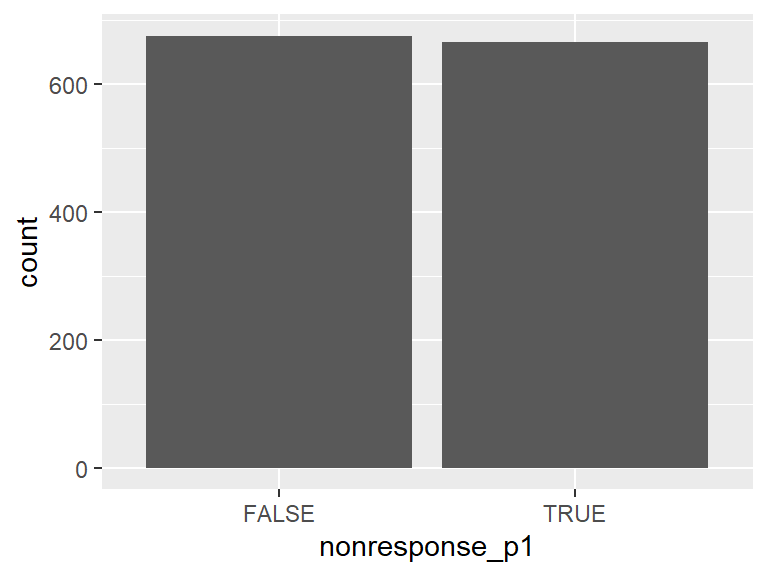

## age_month

*Age (Month)*

| Feature | Result |
| --- | --- |
| Variable type | numeric |
| Number of missing obs. | 0 (0 %) |
| Number of unique values | 49 |
| Median | 15 |
| 1st and 3rd quartiles | 10; 22 |
| Min. and max. | 6; 59 |

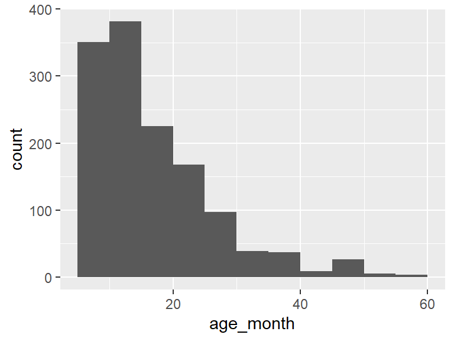

## age_group

*Age group*

| Feature | Result |
| --- | --- |
| Variable type | character |
| Number of missing obs. | 0 (0 %) |
| Number of unique values | 2 |
| Mode | “[6;25[” |

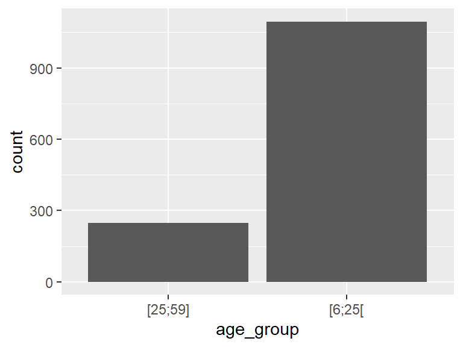

## gender

*Gender*

| Feature | Result |
| --- | --- |
| Variable type | factor |
| Number of missing obs. | 0 (0 %) |
| Number of unique values | 2 |
| Mode | “Male” |
| Reference category | Male |

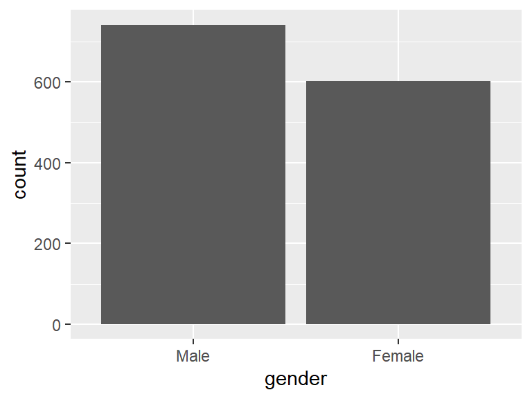

## locality

*Locality*

| Feature | Result |
| --- | --- |
| Variable type | factor |
| Number of missing obs. | 12 (0.89 %) |
| Number of unique values | 2 |
| Mode | “Rural” |
| Reference category | Urban |

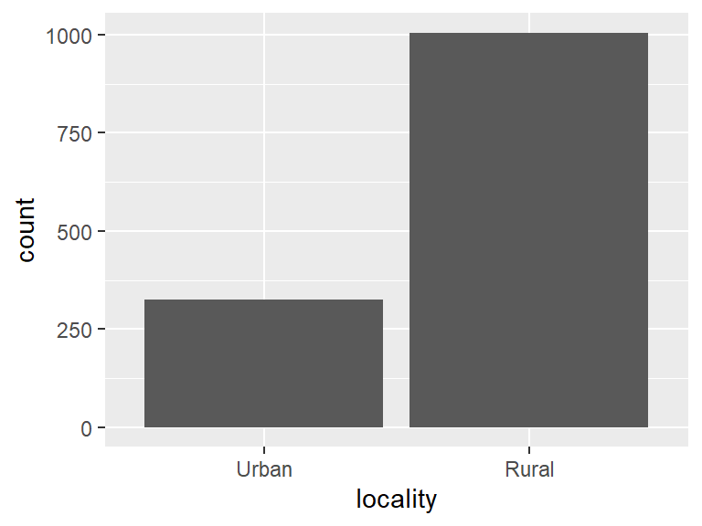

## vaccination_status

*Vaccination status*

| Feature | Result |
| --- | --- |
| Variable type | factor |
| Number of missing obs. | 770 (57.38 %) |
| Number of unique values | 2 |
| Mode | “Up to date” |
| Reference category | Up to date |

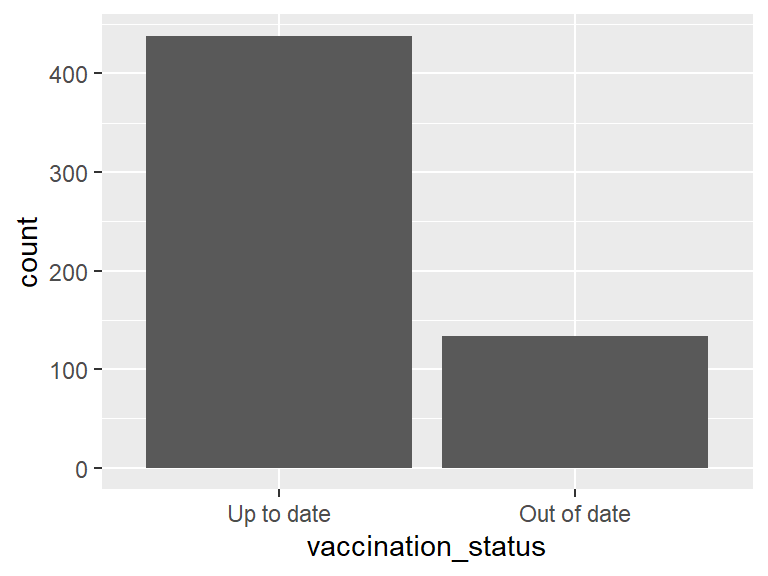

## is_breastfed

*Breastfeeding status*

| Feature | Result |
| --- | --- |
| Variable type | factor |
| Number of missing obs. | 933 (69.52 %) |
| Number of unique values | 2 |
| Mode | “Yes” |
| Reference category | Yes |

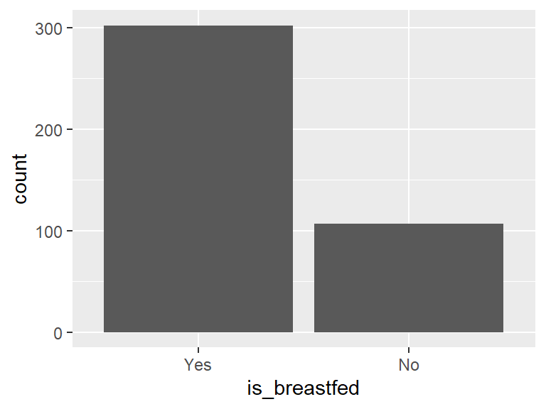

## admission_type

*Type admission*

| Feature | Result |
| --- | --- |
| Variable type | factor |
| Number of missing obs. | 44 (3.28 %) |
| Number of unique values | 2 |
| Mode | “New admission” |
| Reference category | New admission |

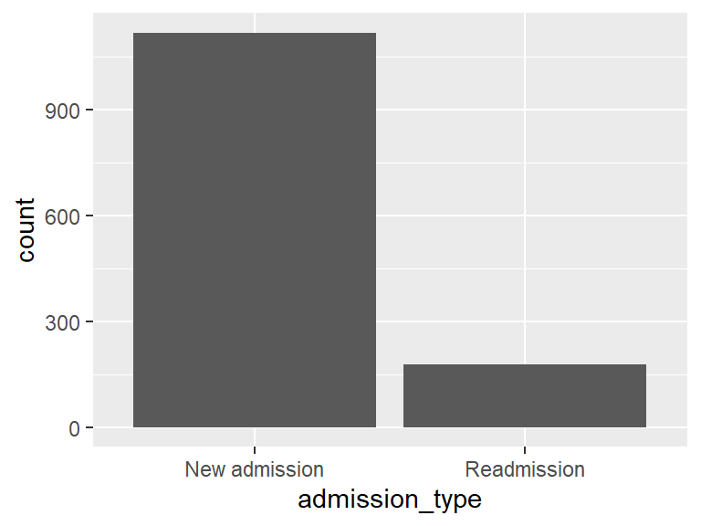

## edema_incident

*Incident edema*

| Feature | Result |
| --- | --- |
| Variable type | logical |
| Number of missing obs. | 0 (0 %) |
| Number of unique values | 2 |
| Mode | “FALSE” |

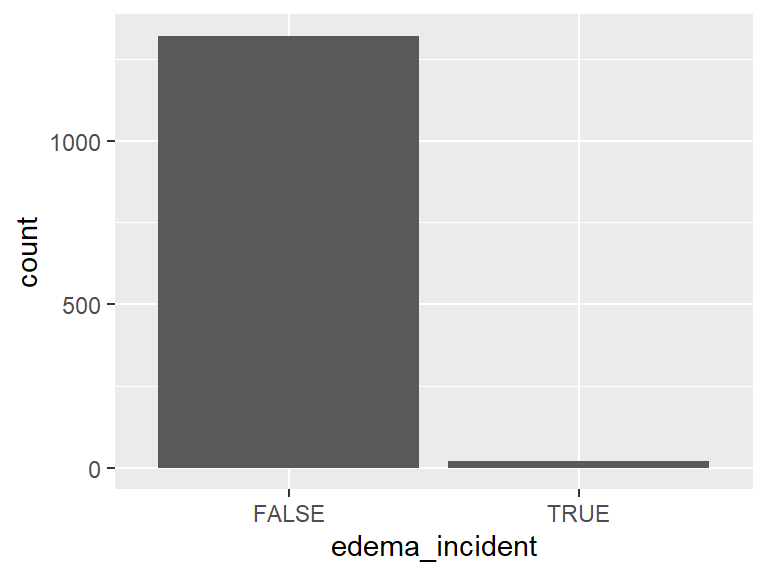

## prop_whz_error_p1

*WHZ error proportion (p1)*

- Note that this variable is treated as a factor variable below, as it only takes a few unique values.

| Feature | Result |
| --- | --- |
| Variable type | numeric |
| Number of missing obs. | 31 (2.31 %) |
| Number of unique values | 3 |
| Mode | “1” |
| Reference category | 0 |

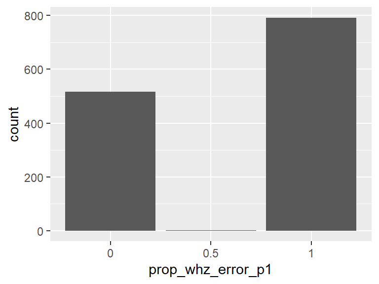

- Note that the following levels have at most five observations: “0.5”.

## length_tubefeeding

*Tube feeding duration*

| Feature | Result |
| --- | --- |
| Variable type | numeric |
| Number of missing obs. | 0 (0 %) |
| Number of unique values | 17 |
| Median | 0 |
| 1st and 3rd quartiles | 0; 0 |
| Min. and max. | 0; 19 |

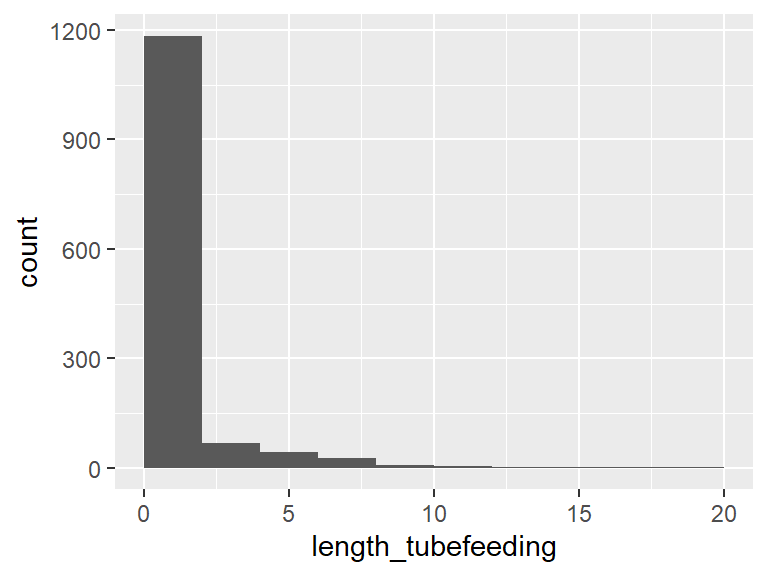

- Note that the following possible outlier values were detected: “1”, “2”, “3”, “4”, “5”, …, “12”, “14”, “16”, “17”, “19” (6 values omitted).

## phase_length

*Phase length*

| Feature | Result |
| --- | --- |
| Variable type | integer |
| Number of missing obs. | 0 (0 %) |
| Number of unique values | 24 |
| Median | 4 |
| 1st and 3rd quartiles | 2; 6 |
| Min. and max. | 1; 33 |

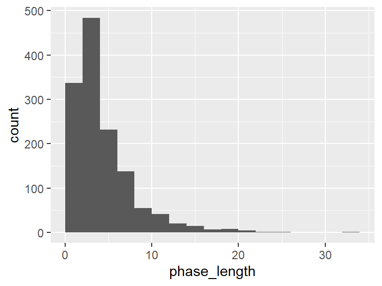

- Note that the following possible outlier values were detected: “24”, “26”, “33”.

## is_death_in_phase

*Death in phase*

| Feature | Result |
| --- | --- |
| Variable type | logical |
| Number of missing obs. | 825 (61.48 %) |
| Number of unique values | 2 |
| Mode | “NA” |

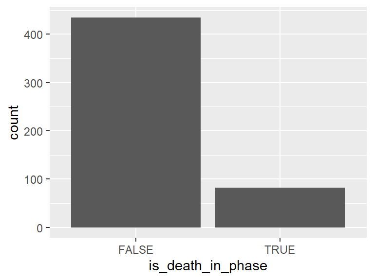

## death_day1_in_phase

*Death on day 1 (P1)*

| Feature | Result |
| --- | --- |
| Variable type | logical |
| Number of missing obs. | 12 (0.89 %) |
| Number of unique values | 2 |
| Mode | “FALSE” |

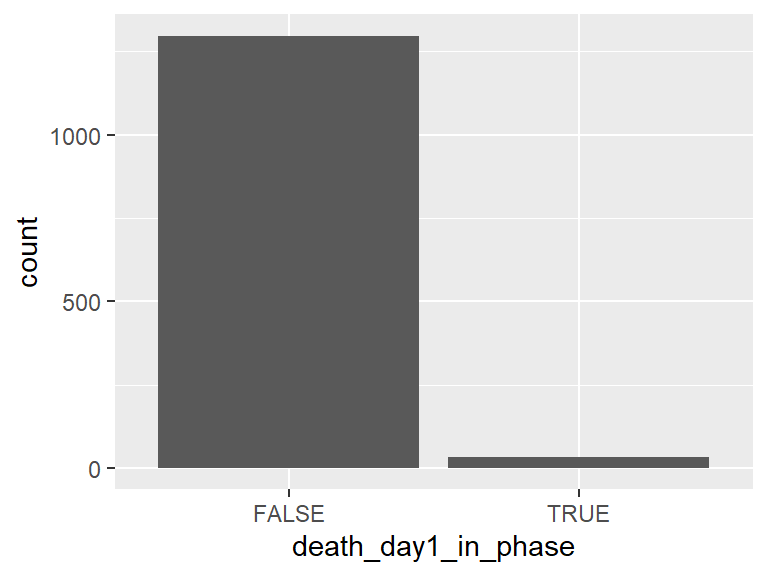

## nutri_treat_p1

*Nutritional treatment (P1)*

| Feature | Result |
| --- | --- |
| Variable type | factor |
| Number of missing obs. | 1 (0.07 %) |
| Number of unique values | 4 |
| Mode | “F75” |
| Reference category | F75 |

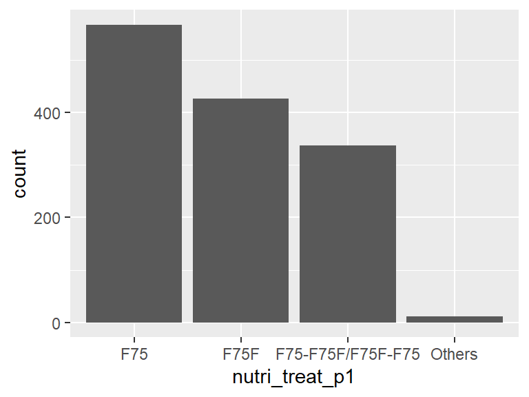

## f75_to_f75f

*F75 to F75F transition*

| Feature | Result |
| --- | --- |
| Variable type | logical |
| Number of missing obs. | 0 (0 %) |
| Number of unique values | 2 |
| Mode | “FALSE” |

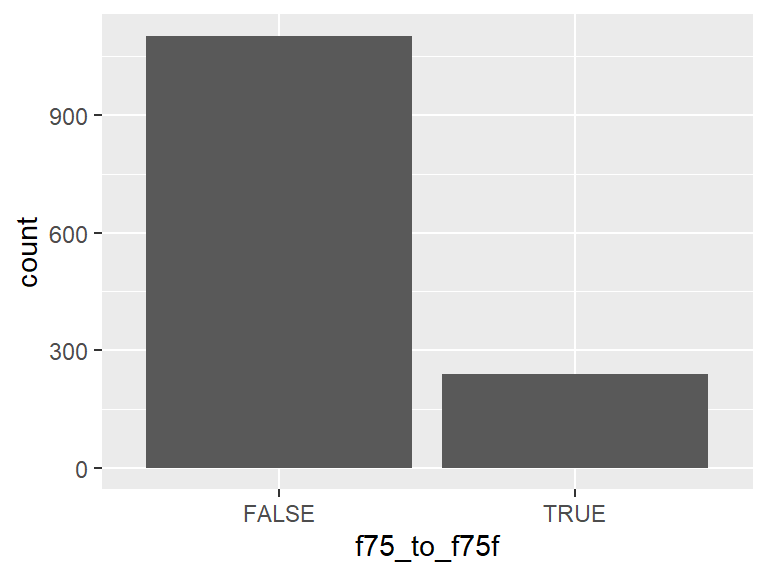

## prop_familymeals_p1

*Family meals proportion (P1)*

| Feature | Result |
| --- | --- |
| Variable type | numeric |
| Number of missing obs. | 0 (0 %) |
| Number of unique values | 18 |
| Median | 0 |
| 1st and 3rd quartiles | 0; 0 |
| Min. and max. | 0; 1 |

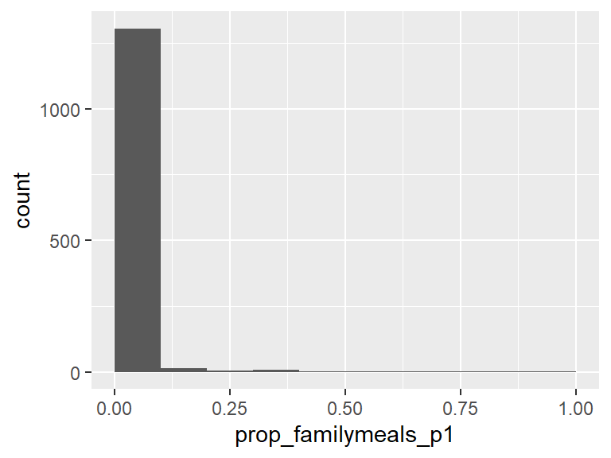

- Note that the following possible outlier values were detected: “0.04”, “0.06”, “0.09”, “0.11”, “0.12”, …, “0.57”, “0.67”, “0.75”, “0.83”, “1” (7 values omitted).

## prop_food_intolerance_p1

*Food intolerance proportion (P1)*

- Note that this variable is treated as a factor variable below, as it only takes a few unique values.

| Feature | Result |
| --- | --- |
| Variable type | numeric |
| Number of missing obs. | 877 (65.35 %) |
| Number of unique values | 2 |
| Mode | “1” |
| Reference category | 0 |

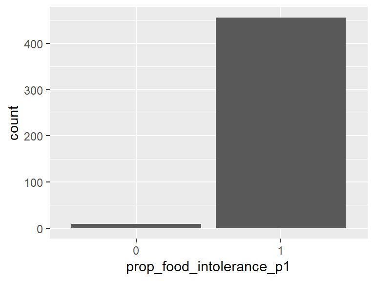

## prop_f75x_freq_less_p1

*F75 frequency below target (P1)*

| Feature | Result |
| --- | --- |
| Variable type | numeric |
| Number of missing obs. | 555 (41.36 %) |
| Number of unique values | 7 |
| Median | 0 |
| 1st and 3rd quartiles | 0; 0 |
| Min. and max. | 0; 1 |

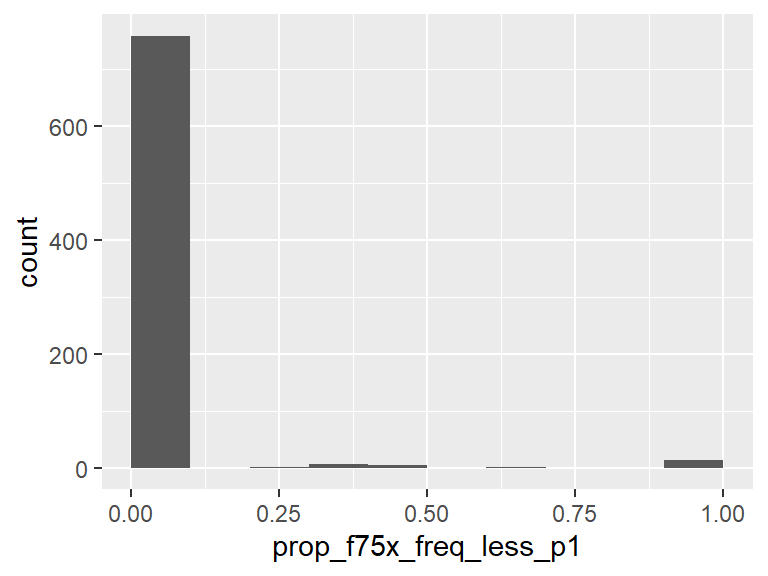

- Note that the following possible outlier values were detected: “0.25”, “0.33”, “0.4”, “0.5”, “0.67”, “1”.

## prop_f75x_freq_more_p1

*F75 frequency above target (P1)*

- Note that this variable is treated as a factor variable below, as it only takes a few unique values.

| Feature | Result |
| --- | --- |
| Variable type | numeric |
| Number of missing obs. | 555 (41.36 %) |
| Number of unique values | 5 |
| Mode | “0” |
| Reference category | 0 |

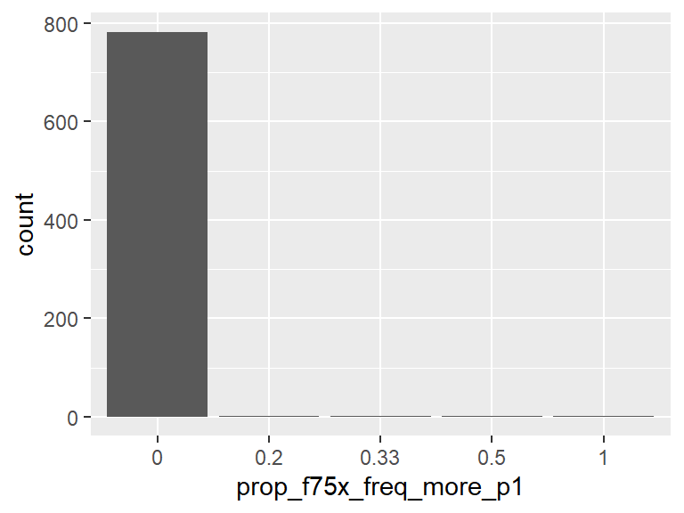

- Note that the following levels have at most five observations: “0.2”, “0.33”, “0.5”, “1”.

## prop_f75x_qty_less_p1

*F75 quantity below target (P1)*

| Feature | Result |
| --- | --- |
| Variable type | numeric |
| Number of missing obs. | 15 (1.12 %) |
| Number of unique values | 28 |
| Median | 0 |
| 1st and 3rd quartiles | 0; 0 |
| Min. and max. | 0; 1 |

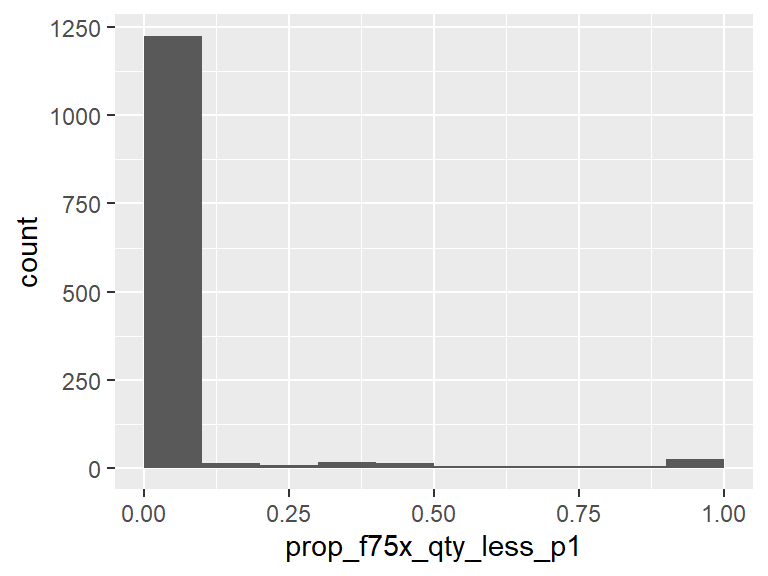

- Note that the following possible outlier values were detected: “0.08”, “0.1”, “0.12”, “0.14”, “0.17”, …, “0.8”, “0.83”, “0.86”, “0.89”, “1” (17 values omitted).

## prop_f75x_qty_more_p1

*F75 quantity above target (P1)*

| Feature | Result |
| --- | --- |
| Variable type | numeric |
| Number of missing obs. | 15 (1.12 %) |
| Number of unique values | 45 |
| Median | 0 |
| 1st and 3rd quartiles | 0; 0.5 |
| Min. and max. | 0; 1 |

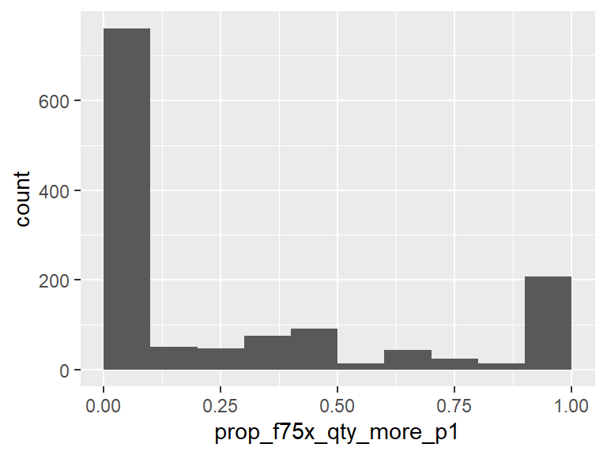

## prop_f75x_adh_less_p1

*F75 adherence below target (P1)*

| Feature | Result |
| --- | --- |
| Variable type | numeric |
| Number of missing obs. | 15 (1.12 %) |
| Number of unique values | 51 |
| Median | 0.25 |
| 1st and 3rd quartiles | 0; 0.5 |
| Min. and max. | 0; 1 |

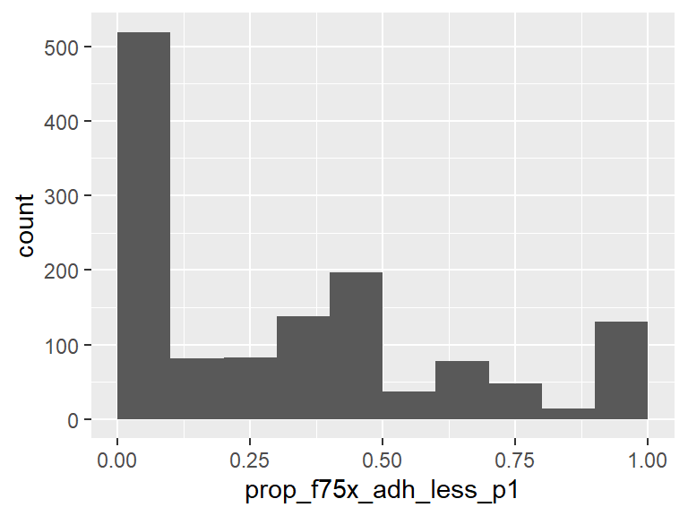

## prop_f75x_adh_more_p1

*F75 adherence above target (P1)*

| Feature | Result |
| --- | --- |
| Variable type | numeric |
| Number of missing obs. | 15 (1.12 %) |
| Number of unique values | 32 |
| Median | 0 |
| 1st and 3rd quartiles | 0; 0 |
| Min. and max. | 0; 1 |

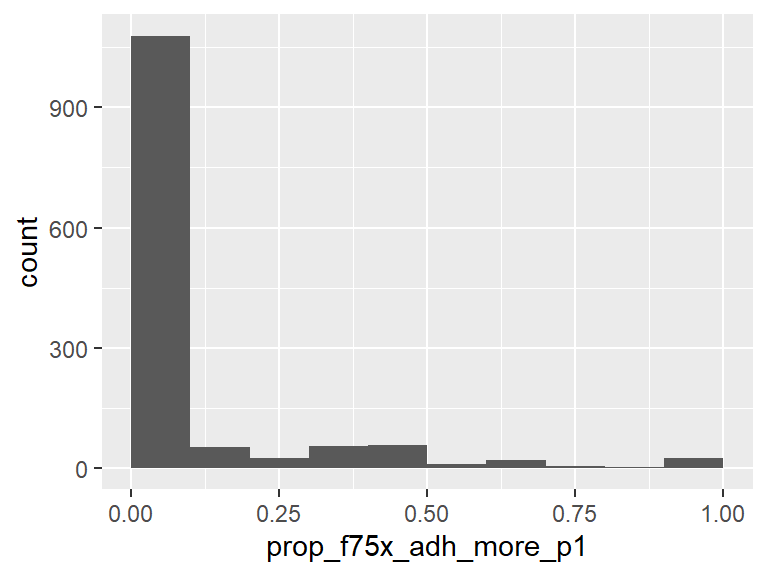

- Note that the following possible outlier values were detected: “0.05”, “0.06”, “0.08”, “0.09”, “0.1”, …, “0.75”, “0.76”, “0.8”, “0.83”, “1” (21 values omitted).

## morbidite

*Morbidity burden*

| Feature | Result |
| --- | --- |
| Variable type | numeric |
| Number of missing obs. | 0 (0 %) |
| Number of unique values | 7 |
| Median | 2 |
| 1st and 3rd quartiles | 1; 3 |
| Min. and max. | 0; 6 |

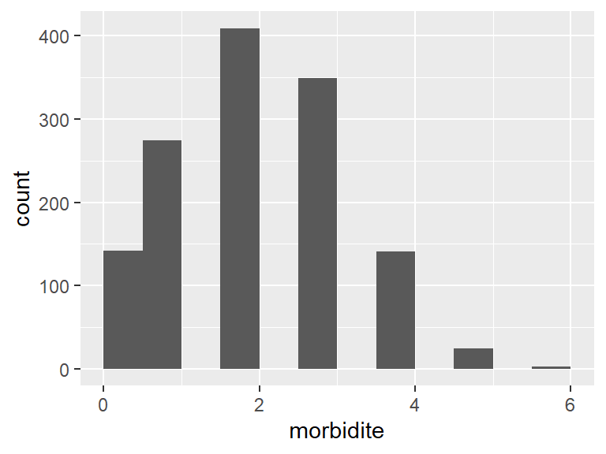

## has_shock

*Shock*

| Feature | Result |
| --- | --- |
| Variable type | logical |
| Number of missing obs. | 71 (5.29 %) |
| Number of unique values | 2 |
| Mode | “FALSE” |

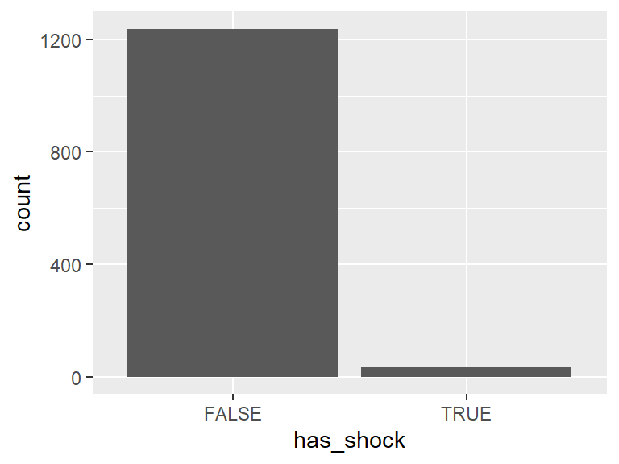

## has_gastroenteritis

*Gastroenteritis*

| Feature | Result |
| --- | --- |
| Variable type | logical |
| Number of missing obs. | 71 (5.29 %) |
| Number of unique values | 2 |
| Mode | “TRUE” |

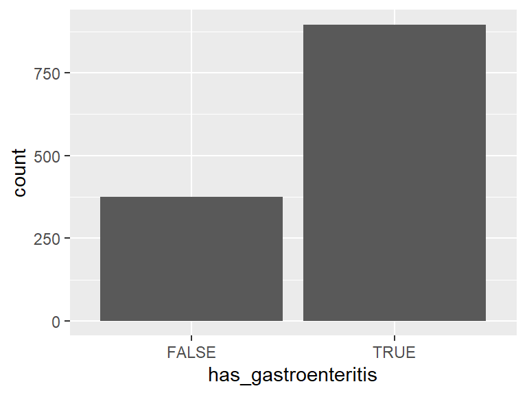

## has_pneumonia

*Pneumonia*

| Feature | Result |
| --- | --- |
| Variable type | logical |
| Number of missing obs. | 71 (5.29 %) |
| Number of unique values | 2 |
| Mode | “TRUE” |

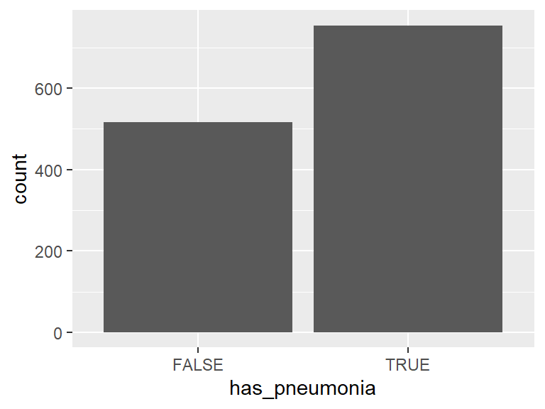

## has_tuberculosis

*Tuberculosis*

| Feature | Result |
| --- | --- |
| Variable type | logical |
| Number of missing obs. | 71 (5.29 %) |
| Number of unique values | 2 |
| Mode | “FALSE” |

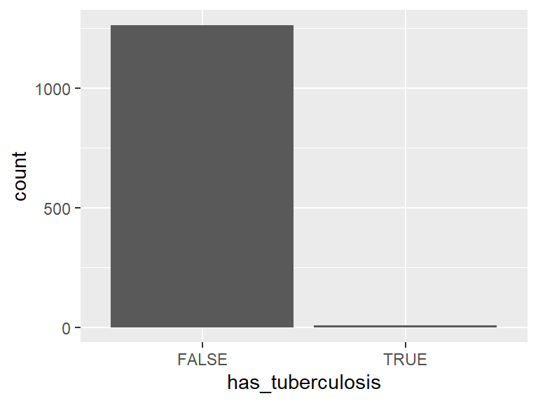

## has_digestive_candidiasis

*Digestive candidiasis*

| Feature | Result |
| --- | --- |
| Variable type | logical |
| Number of missing obs. | 71 (5.29 %) |
| Number of unique values | 2 |
| Mode | “FALSE” |

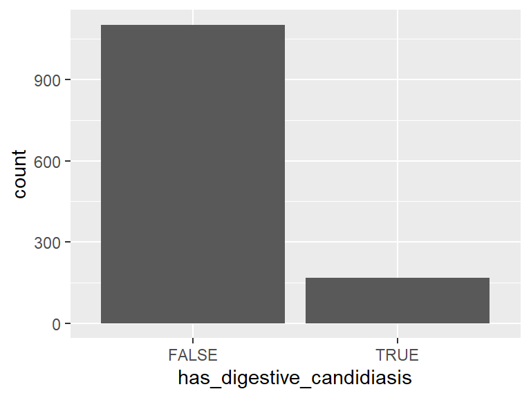

## has_hiv

*HIV*

| Feature | Result |
| --- | --- |
| Variable type | logical |
| Number of missing obs. | 71 (5.29 %) |
| Number of unique values | 2 |
| Mode | “FALSE” |

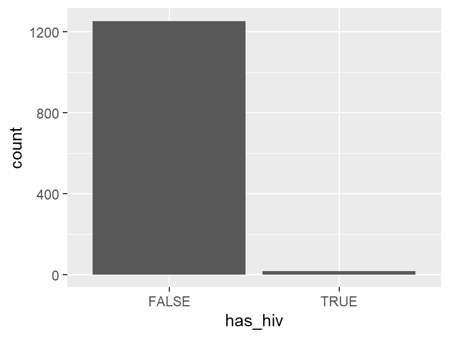

## has_severe_malaria

*Severe malaria*

| Feature | Result |
| --- | --- |
| Variable type | logical |
| Number of missing obs. | 0 (0 %) |
| Number of unique values | 2 |
| Mode | “FALSE” |

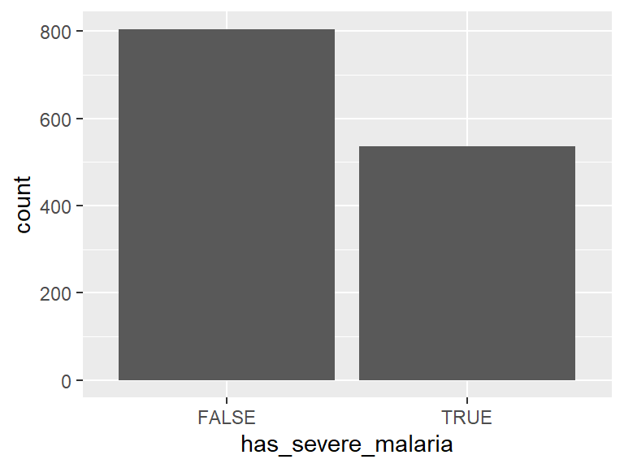

## has_neuro_malaria

*Neurological malaria*

| Feature | Result |
| --- | --- |
| Variable type | logical |
| Number of missing obs. | 71 (5.29 %) |
| Number of unique values | 2 |
| Mode | “FALSE” |

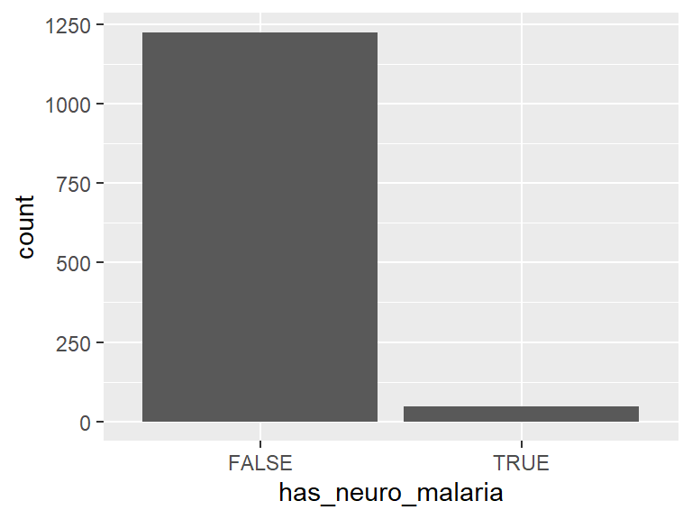

## has_severe_anaemia

*Severe anemia*

| Feature | Result |
| --- | --- |
| Variable type | logical |
| Number of missing obs. | 71 (5.29 %) |
| Number of unique values | 2 |
| Mode | “FALSE” |

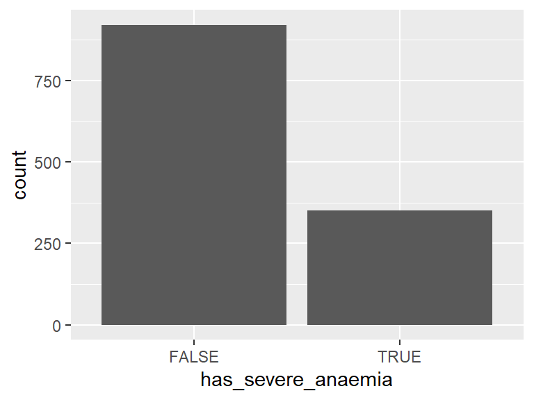

## has_other_anemia

*Other anemia*

| Feature | Result |
| --- | --- |
| Variable type | logical |
| Number of missing obs. | 71 (5.29 %) |
| Number of unique values | 2 |
| Mode | “FALSE” |

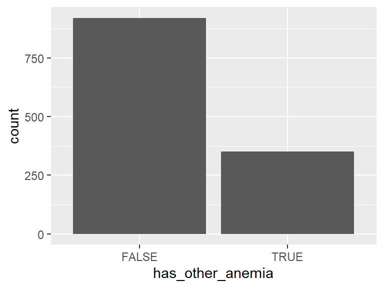

## discharge_type_p1

*Type of discharge (P1)*

| Feature | Result |
| --- | --- |
| Variable type | factor |
| Number of missing obs. | 825 (61.48 %) |
| Number of unique values | 3 |
| Mode | “Recovered/Transferred” |
| Reference category | Recovered/Transferred |

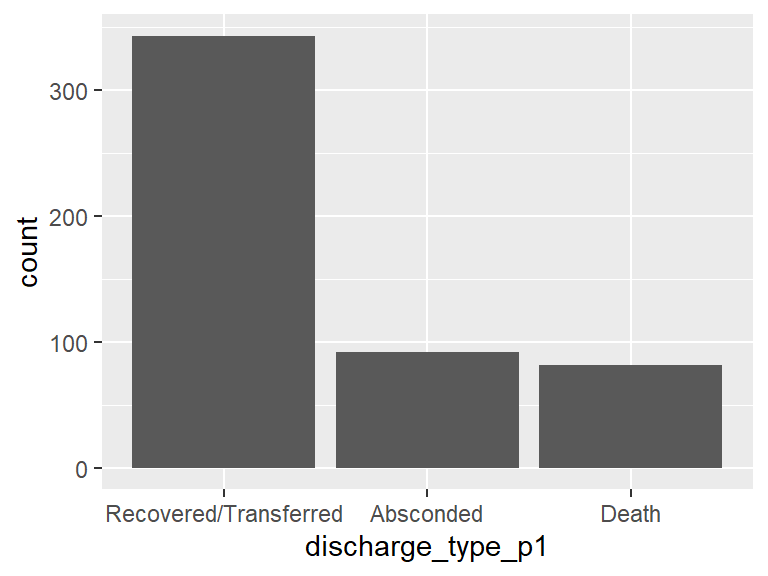

## prop_f75x_adh_less_level_p1

*F75 adherence below target (P1)*

| Feature | Result |
| --- | --- |
| Variable type | factor |
| Number of missing obs. | 15 (1.12 %) |
| Number of unique values | 2 |
| Mode | “]0;100]” |
| Reference category | 0 |

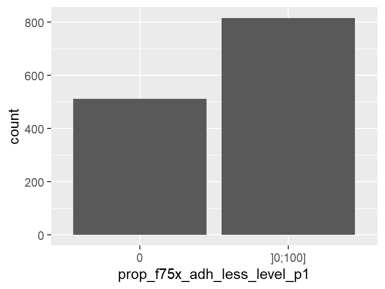

Report generation information:

- Created by: Doubata (username: `DELL`).
- Report creation time: dim. juil. 12 2026 15:20:45
- Report was run from directory: `C:/Users/DELL/Documents/CREN/crenMalnutrition`
- dataReporter v1.0.5 [Pkg: 2025-04-13 from standard ( @1.0.5)]
- R version 4.6.1 (2026-06-24 ucrt).
- Platform: x86_64-w64-mingw32/x64(Africa/Ouagadougou).
- Function call: `makeDataReport(data = cohort_p1_data_c659_noedema, output = "html", render = FALSE, file = "reports/dq_cohort_p1_c659_noedema.Rmd", replace = TRUE)`